# Intro to Plotting in R

### How do I make changes to the legend in ggplot?

### How do I change the position of the legend in ggplot?

### How do I change the title over the legend?

### How do I change the font of the *title* of the legend in ggplot?

### How do I change the font of the *labels* of the legend in ggplot?

```r
#keywords: ggplot, legend, font, bold,
theme(
  legend.position="right",
  #legend.position=c(0.15, .85),
  legend.title = element_text(colour="black",
                              size=24,
                              face="bold"),
  legend.text = element_text(colour="black",
                             size = 20,
                             face = "bold")) +
```

### How do I change the thickness of the axes in ggplot?

```r
theme(axis.line = element_line(size=2, color = "black"))    #makes axes lines thicker
```

### How do I get rid of/remove/suppress the box around the plotting field

```r
# keywords: box, border, edging, around blot
 theme(panel.border = element_rect(color = "white"))
```

#### How do I get rid of the box around…

```r
# keywords: box, border, edging, around blot
theme(legend.key = element_rect(colour = 'white')) +   # gets rid of box around length key items
```

#### How do I get rid of the grid lines within the plot in ggplot?

```r
 theme(panel.grid.minor=element_blank(),
       panel.grid.major=element_blank())
```

```
## List of 2
##  $ panel.grid.major: list()
##   ..- attr(*, "class")= chr [1:2] "element_blank" "element"
##  $ panel.grid.minor: list()
##   ..- attr(*, "class")= chr [1:2] "element_blank" "element"
##  - attr(*, "class")= chr [1:2] "theme" "gg"
##  - attr(*, "complete")= logi FALSE
##  - attr(*, "validate")= logi TRUE
```

#### How do I set the font of the axes titles?

#### How do I adjust the positions of the axes titles?

```r
theme(axis.title.x = element_text(face="bold", size=32),
      axis.text.x  = element_text(vjust=0.95,
      size=32,
      face="bold"),
      axis.title.y = element_text(face="bold",
              size=32,
            vjust=0.35),
              axis.text.y  = element_text(vjust=0.5,
              size=32,face="bold"))
```

```
## List of 4
##  $ axis.title.x:List of 11
##   ..$ family       : NULL
##   ..$ face         : chr "bold"
##   ..$ colour       : NULL
##   ..$ size         : num 32
##   ..$ hjust        : NULL
##   ..$ vjust        : NULL
##   ..$ angle        : NULL
##   ..$ lineheight   : NULL
##   ..$ margin       : NULL
##   ..$ debug        : NULL
##   ..$ inherit.blank: logi FALSE
##   ..- attr(*, "class")= chr [1:2] "element_text" "element"
##  $ axis.title.y:List of 11
##   ..$ family       : NULL
##   ..$ face         : chr "bold"
##   ..$ colour       : NULL
##   ..$ size         : num 32
##   ..$ hjust        : NULL
##   ..$ vjust        : num 0.35
##   ..$ angle        : NULL
##   ..$ lineheight   : NULL
##   ..$ margin       : NULL
##   ..$ debug        : NULL
##   ..$ inherit.blank: logi FALSE
##   ..- attr(*, "class")= chr [1:2] "element_text" "element"
##  $ axis.text.x :List of 11
##   ..$ family       : NULL
##   ..$ face         : chr "bold"
##   ..$ colour       : NULL
##   ..$ size         : num 32
##   ..$ hjust        : NULL
##   ..$ vjust        : num 0.95
##   ..$ angle        : NULL
##   ..$ lineheight   : NULL
##   ..$ margin       : NULL
##   ..$ debug        : NULL
##   ..$ inherit.blank: logi FALSE
##   ..- attr(*, "class")= chr [1:2] "element_text" "element"
##  $ axis.text.y :List of 11
##   ..$ family       : NULL
##   ..$ face         : chr "bold"
##   ..$ colour       : NULL
##   ..$ size         : num 32
##   ..$ hjust        : NULL
##   ..$ vjust        : num 0.5
##   ..$ angle        : NULL
##   ..$ lineheight   : NULL
##   ..$ margin       : NULL
##   ..$ debug        : NULL
##   ..$ inherit.blank: logi FALSE
##   ..- attr(*, "class")= chr [1:2] "element_text" "element"
##  - attr(*, "class")= chr [1:2] "theme" "gg"
##  - attr(*, "complete")= logi FALSE
##  - attr(*, "validate")= logi TRUE
```

#### How do I drop, remove or suppress the legend in ggplot?

```r
theme(legend.position = "none")
```

#### Remove facet strip completely

http://stackoverflow.com/questions/10547487/r-removing-facet-wrap-labels-completely-in-ggplot2

```r
theme(strip.background = element_blank(),
       strip.text.x = element_blank())
```

#### How do I increase the size text of the within facets?

#### How do I increase the font size of facet labels?

http://stackoverflow.com/questions/2751065/how-can-i-manipulate-the-strip-text-of-facet-plots-in-ggplot2/2751201#2751201

```r
theme(strip.text.x = element_text(size = 8, colour = "orange", angle = 90))
```

#### How do I reorder a factor variable for plotting in ggplot?

```r
levs <- mult.comp.df$names.ordered[order.x]
mult.comp.df$names.ordered <- factor(mult.comp.df$names.ordered,
                                     levels = levs)
```

#### colorblind palletes

color blind palletes http://dr-k-lo.blogspot.com/2013/07/a-color-blind-friendly-palette-for-r.html http://www.cookbook-r.com/Graphs/Colors_%28ggplot2%29/

#mult.comp.df$names <- with(mult.comp.df, reorder(names, coefficients, function(x) -order(x)))

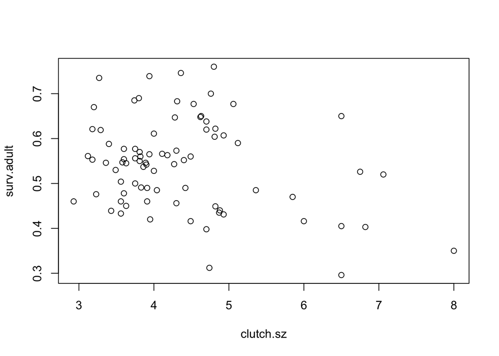

```r
plot(surv.adult ~ clutch.sz, data = martin)
```

Plot distribution of survival rates

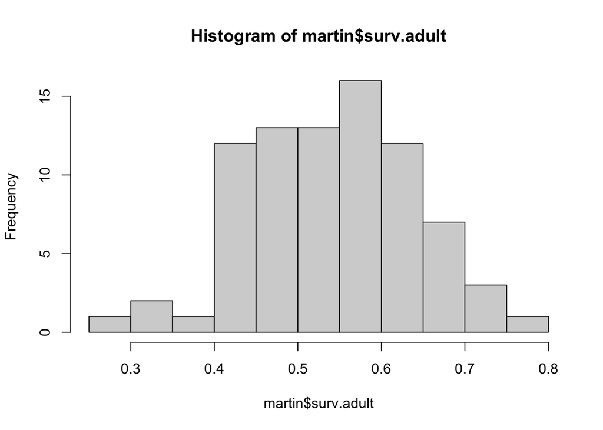

```r
hist(martin$surv.adult)
```

Plot distribution of clutch sizes

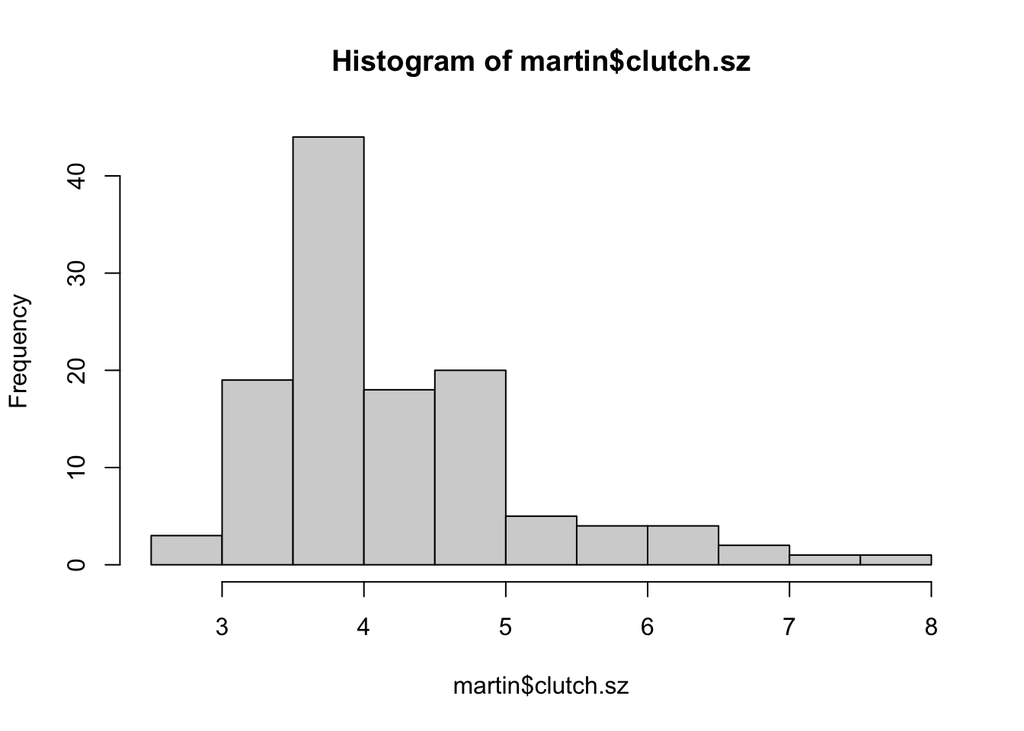

```r
hist(martin$clutch.sz)
```

Load ggplot package

```r
library(ggplot2)
```

Plot distribution of clutch sizes in ggplot

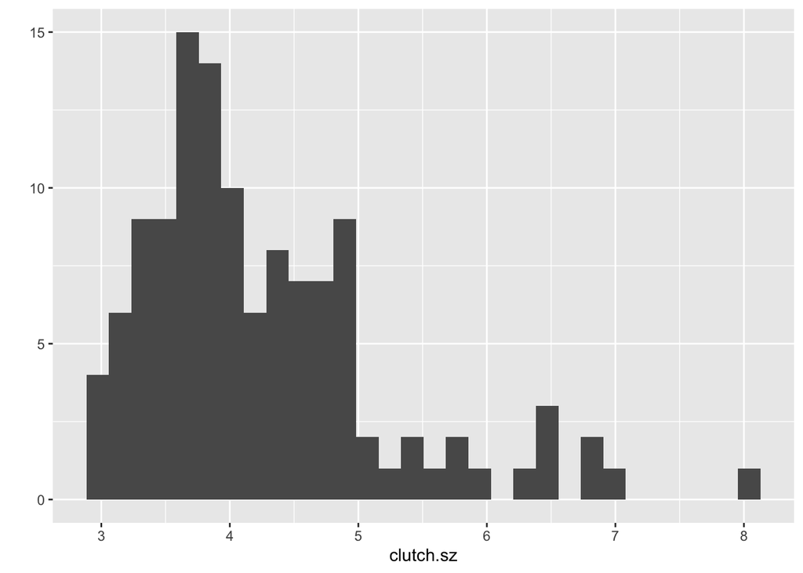

```r
qplot(clutch.sz,
       data = martin)
```

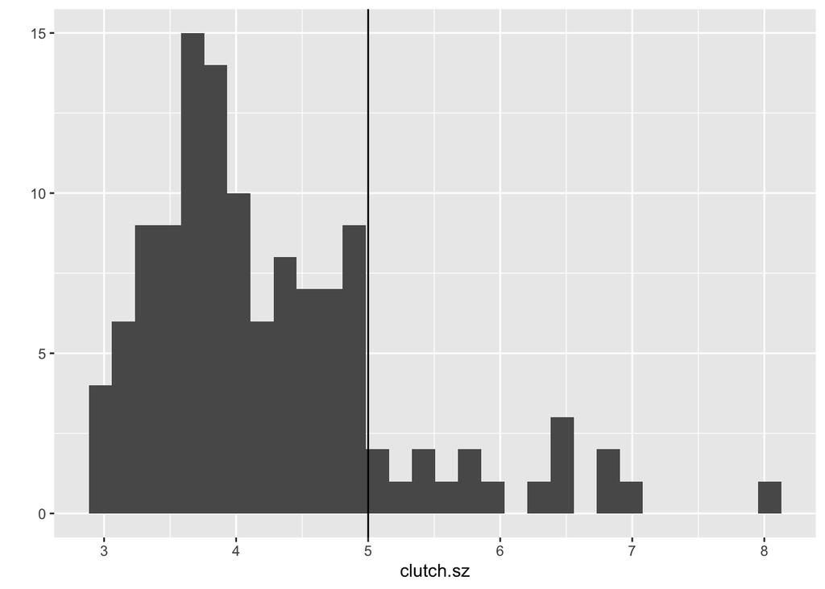

```r
qplot(clutch.sz,
       data = martin) + geom_vline(xintercept = 5)
```

Add labels

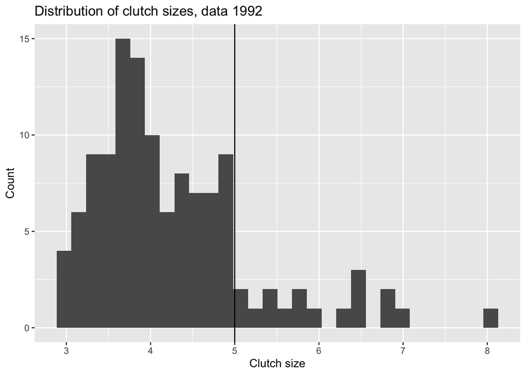

```r
qplot(clutch.sz,
       data = martin) +
  geom_vline(xintercept = 5) +
  xlab("Clutch size") +
  ylab("Count") +
  ggtitle("Distribution of clutch sizes, data 1992")
```

Make background white

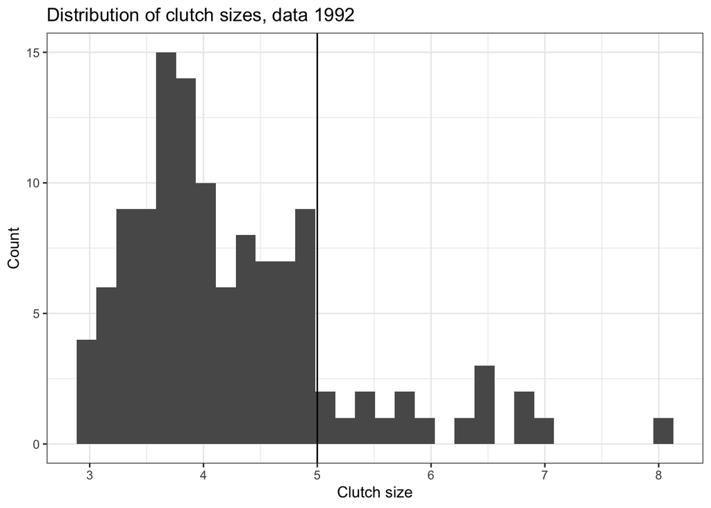

```r
qplot(clutch.sz,
       data = martin) +
  geom_vline(xintercept = 5) +
  xlab("Clutch size") +
  ylab("Count") +
  ggtitle("Distribution of clutch sizes, data 1992") +
  theme(axis.text=element_text(size=18),
        axis.title=element_text(size=22,face="bold")) +
  theme_bw()
```

Plot as density curve

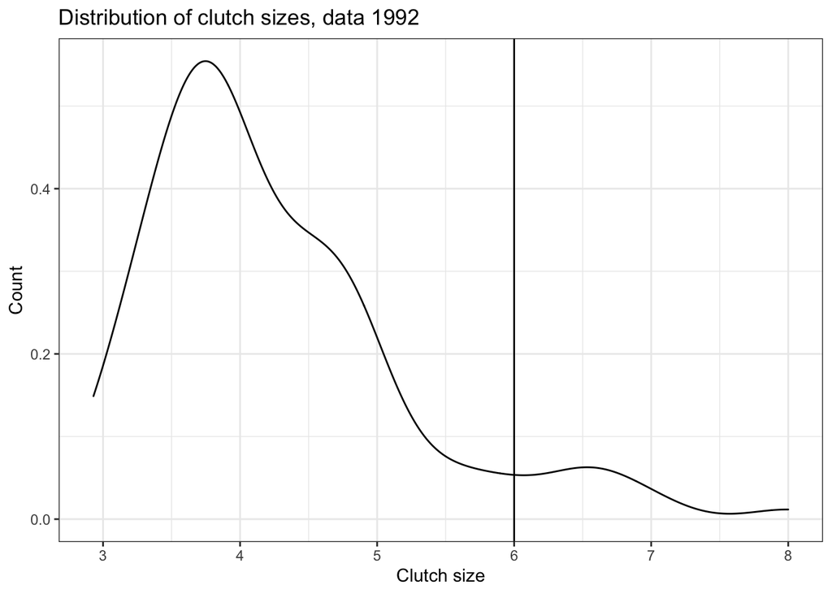

```r
qplot(clutch.sz,
       data = martin,
      geom = "density") +
  geom_vline(xintercept = 6) +
  xlab("Clutch size") +
  ylab("Count") +
  ggtitle("Distribution of clutch sizes, data 1992") +
  theme(axis.text=element_text(size=18),
        axis.title=element_text(size=22,face="bold")) +
  theme_bw()
```

Plot as separate density curve for each nest type group

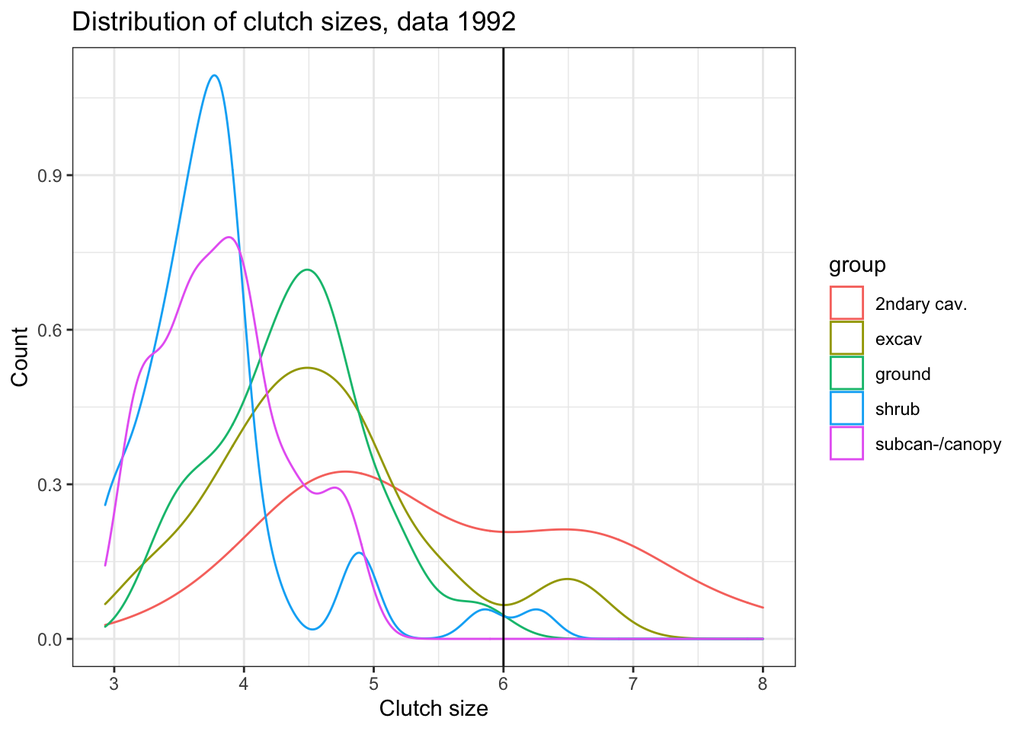

```r
qplot(clutch.sz,
       data = martin,
      geom = "density",
      color = group,
      group = group) +
  geom_vline(xintercept = 6) +
  xlab("Clutch size") +
  ylab("Count") +
  ggtitle("Distribution of clutch sizes, data 1992") +
  theme(axis.text=element_text(size=18),
        axis.title=element_text(size=22,face="bold")) +
  theme_bw()
```

Plot distribution of clutch sizes by FORAGING site

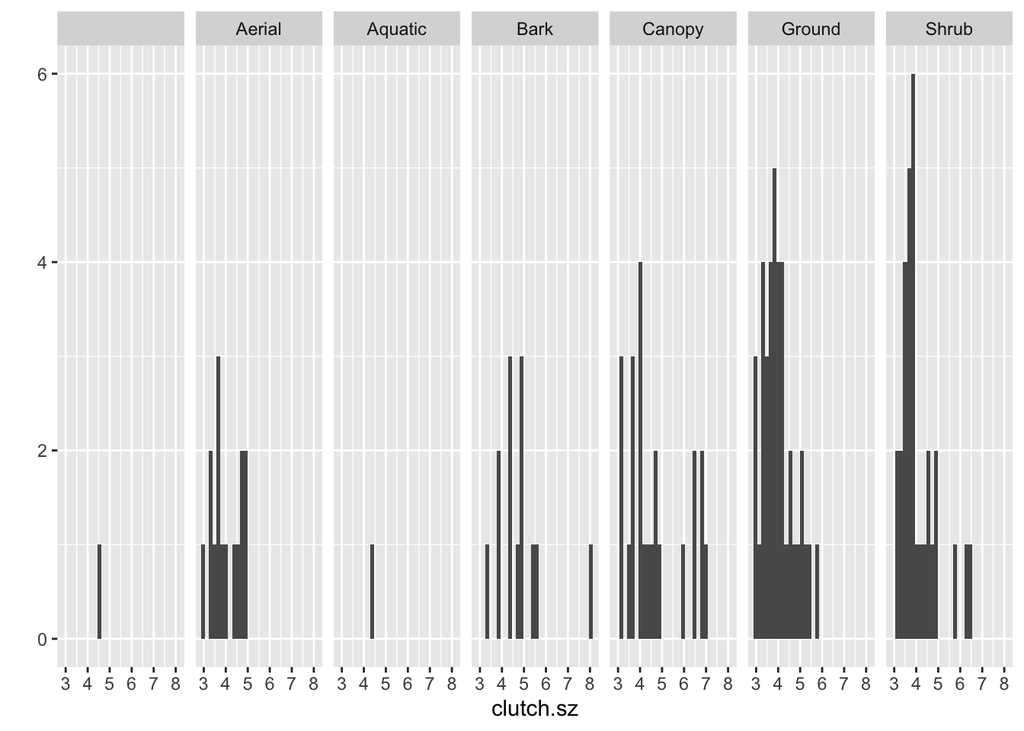

```r
qplot(clutch.sz,
       data = martin,
      facets = . ~ foraging.site)
```

Use facet wrap

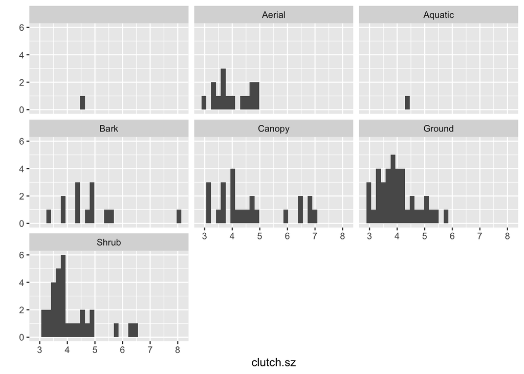

```r
qplot(clutch.sz,
       data = martin) +
  facet_wrap(~foraging.site)
```

Plot distribution of clutch sizes by habitat group

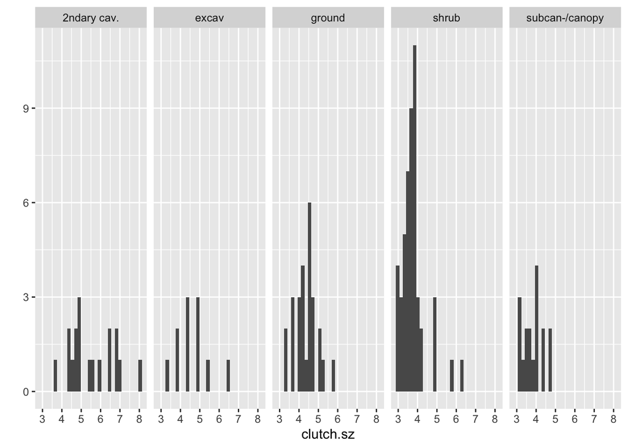

```r
qplot(clutch.sz,
       data = martin,
      facets = . ~ group)
```

Boxplot

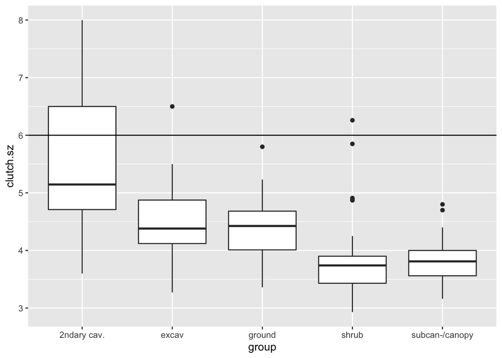

```r
qplot(y = clutch.sz,
      x = group,
      geom = "boxplot",
       data = martin) +
  geom_hline(yintercept = 6)
```

Incubation period vs. predation

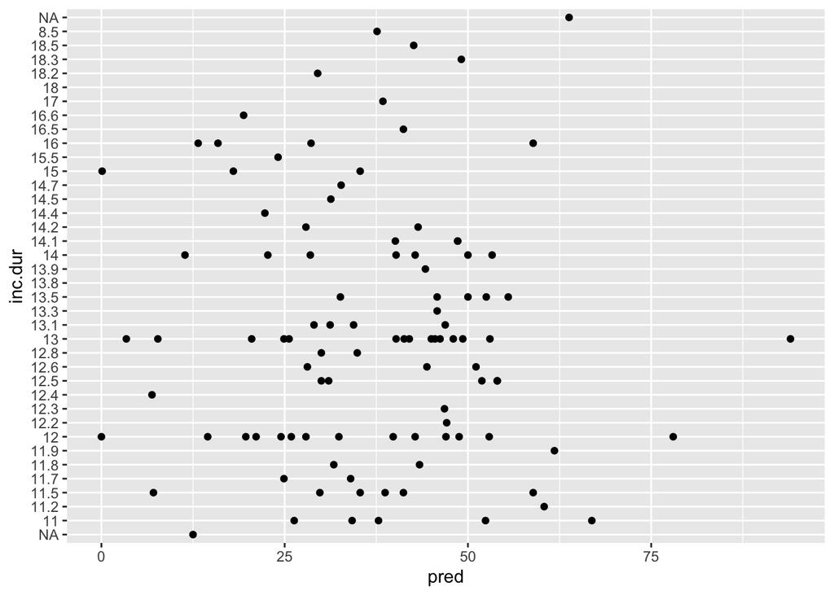

```r
qplot(y = inc.dur,
      x = pred,
      data = martin)
```

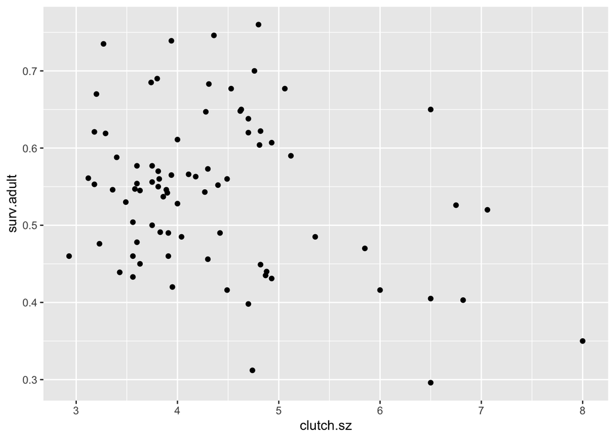

```r
qplot(y = surv.adult,
      x = clutch.sz,
      data = martin)
```

Plot adult survival versus duration of incubation in ggplot

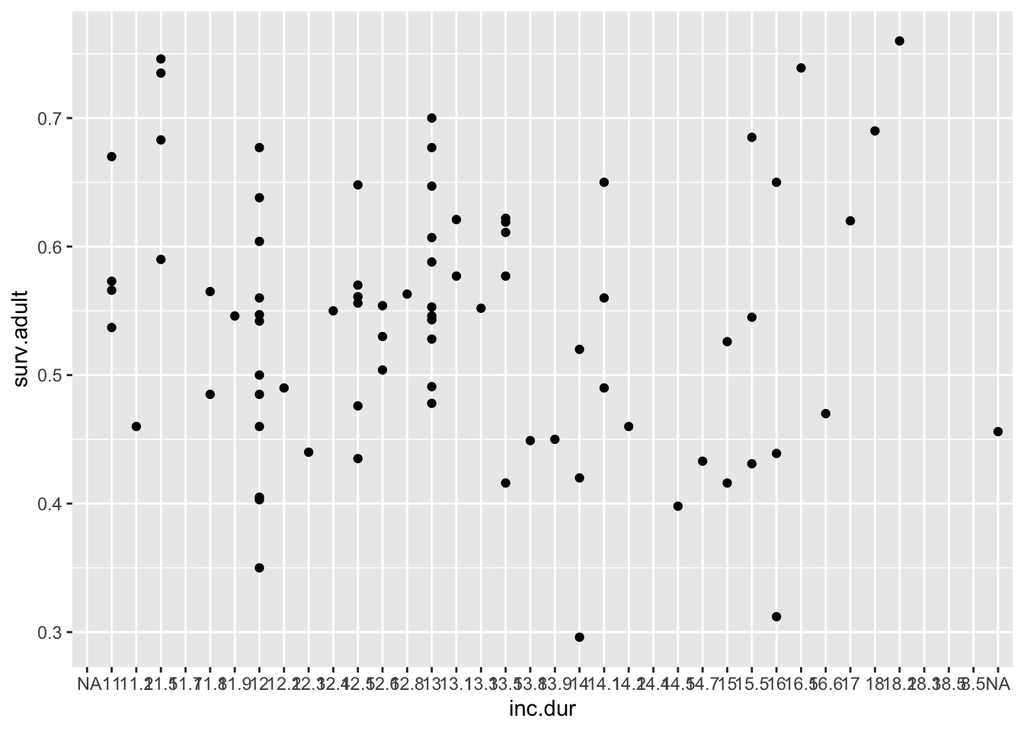

```r
qplot(y = surv.adult,
      x = inc.dur,
      data = martin)
```

Add a trend line

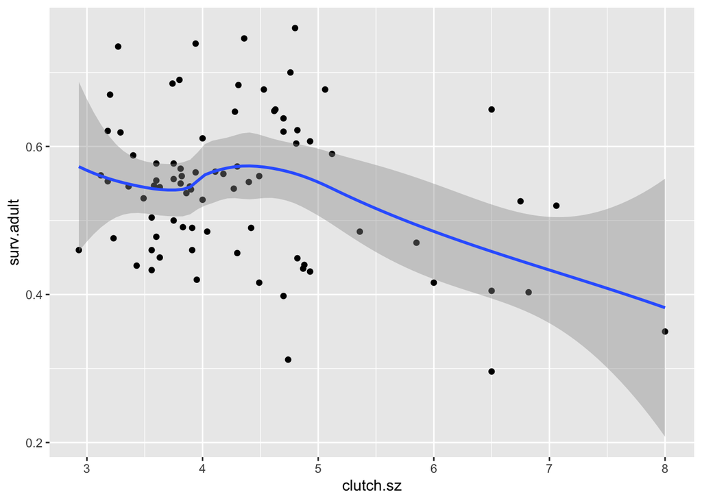

```r
qplot(y = surv.adult,
      x = clutch.sz,
      data = martin,
      geom = c("point","smooth"))
```

Color code each group

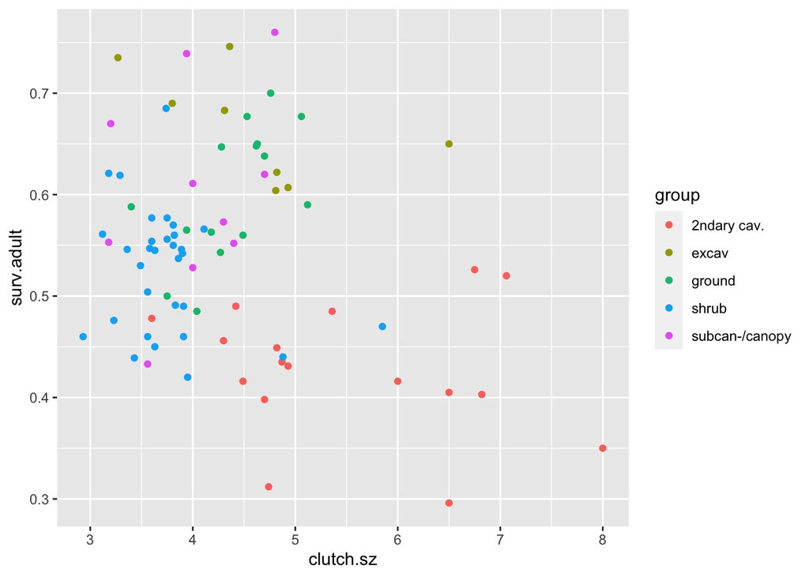

```r
qplot(y = surv.adult,
      x = clutch.sz,
      data = martin,
      color = group)
```

Make size of points bigger

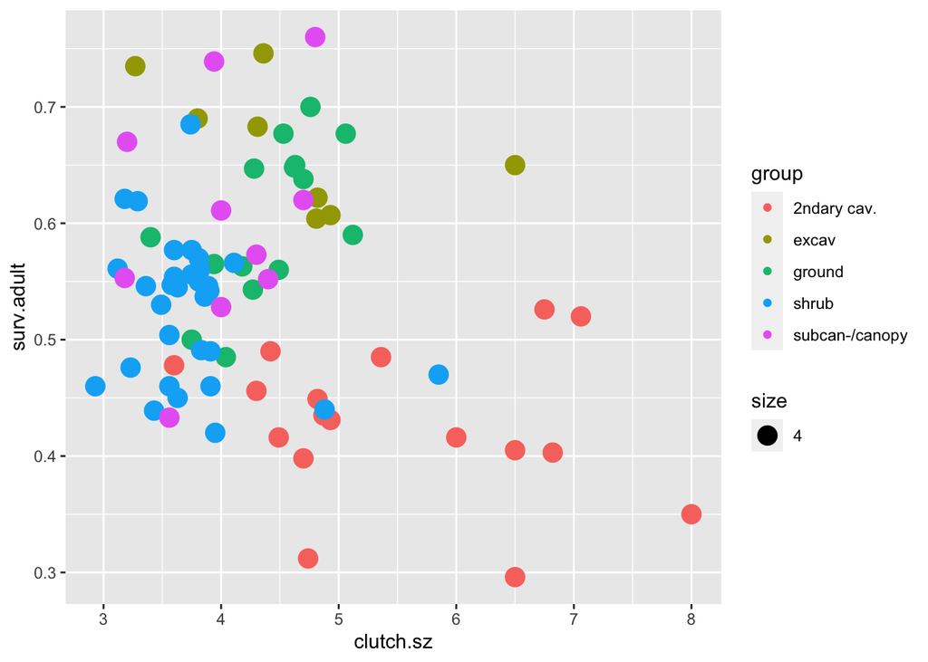

```r
qplot(y = surv.adult,
      x = clutch.sz,
      data = martin,
      color = group,
      size = 4)
```

Add trend line to each group

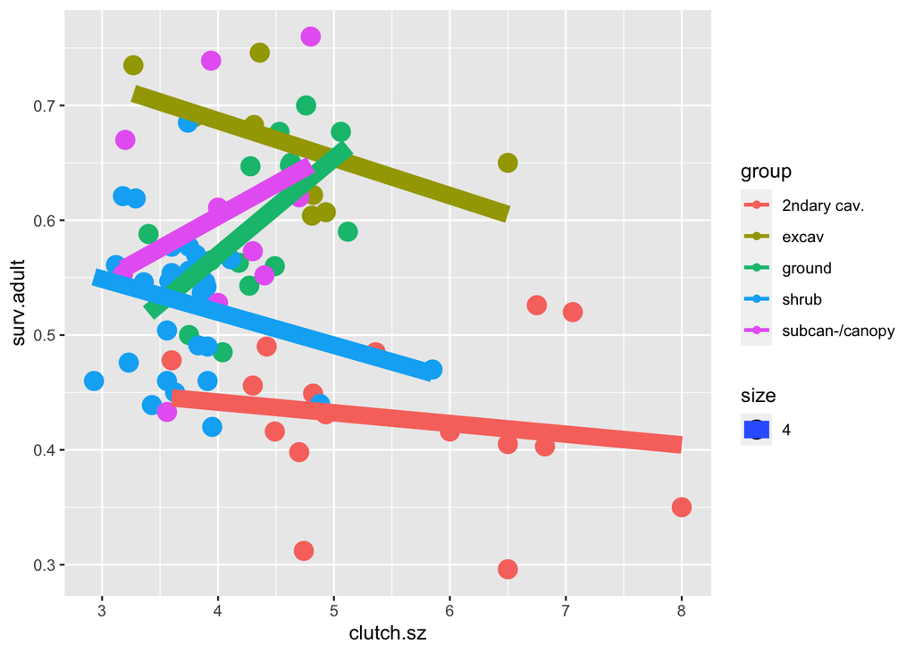

```r
qplot(y = surv.adult,
      x = clutch.sz,
      data = martin,
      color = group,
      geom = c("point","smooth"),
      method = "lm",
      se = FALSE,
      size = 4)
```

Figure out which species have “warbler” in their name

```r
martin$warbler <- "not warbler"
martin$warbler[grep("Warb", martin$spp)] <- "warbler"
```

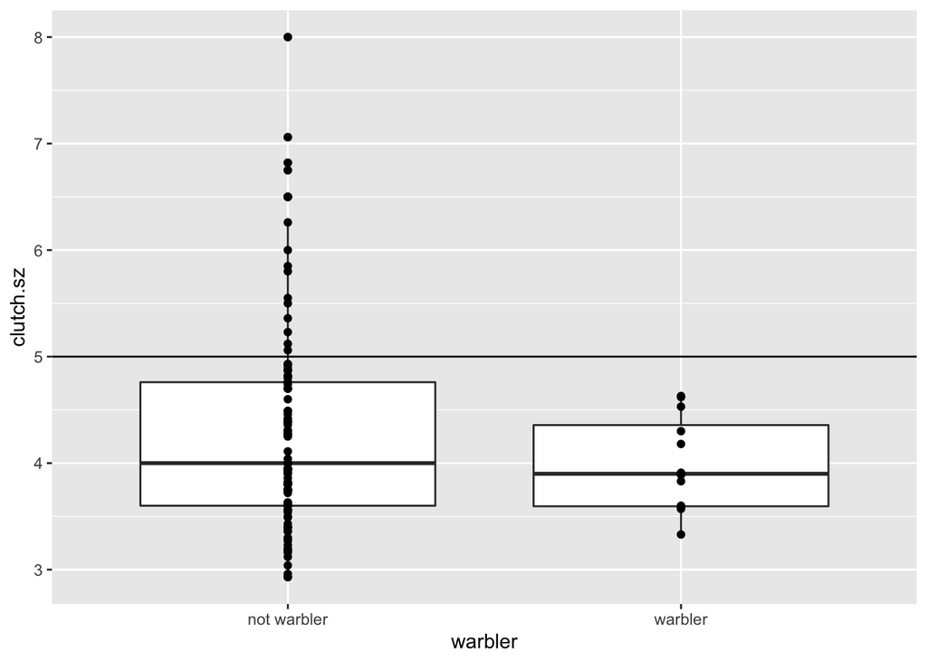

```r
qplot(y = clutch.sz,
      x = warbler,
      geom = c("boxplot","point"),
      data = martin) + geom_hline(yintercept = 5)
```

## save ggplot

```r
ggsave(...)
```